# Devoir 1

*Disponible sur ce [site](https://thibaud-ritzenthaler.github.io/M1demo-AD-devoir1/), le code source sur [Github](https://github.com/thibaud-ritzenthaler/M1demo-AD-devoir1)*.

## Exercice 1

** 3 tables car deux manières de sortir de la table: la mortalité accidentelle et par maladie en brut et la mortalité réunie en net** ### Partie I : la mortalité des hommes et des femmes *On se propose d’étudier la mortalité d’une génération non soumise aux migrations, en l’absence d’autres causes de décès. On a construit la table masculine et féminine de mortalité générale (Table I M et I F), la table masculine de mortalité par accident (Table II M) et la table féminine de mortalité par toutes autres causes, ou table de mortalité par maladie (table III F) de cette génération.*

*a- Construire la table masculine de mortalité par toutes les causes autres que les accidents (ou table masculine par « maladie » de cette génération). L’appeler Table III M.*

La Table III M. est la table de ceux qui ont subi le phénomène de la mortalité, mais qui n’ont pas subi le phénomène de mortalité suite à un accident. On peut calculer son quotient pour chaque âge en prenant le quotient de mortalité par accident pour chaque âge et en le soustrayant au quotient de mortalité générale pour chaque âge.

On calcule ensuite le taux brut de mortalité maladive pour chaque âge. **Ne pas mettre le code, mettre l’explication plutôt en formule mathématique, voir LaTex**

```r
Racine <- 100000
TableMortMascMaladie <- TableMortMascGeneral %>%
  select("aqx p.1000")
for (i in seq_along(row.names(TableMortMascMaladie))) {
  TableMortMascMaladie$`Sx`[i] <- Racine
  TableMortMascMaladie$`aqx p.1000`[i] <- round((1 - ((1 - (TableMortMascGeneral$`aqx p.1000`[i]/1000))/(1 - (TableMortMascAccident$`aqx p.1000`[i] /1000)))) * 1000, 2)
  TableMortMascMaladie$`d(x;x+a)`[i] <- round(Racine * (TableMortMascMaladie$`aqx p.1000`[i] * 0.001))
  Racine <- Racine - TableMortMascMaladie$`d(x;x+a)`[i]
}
TableMortMascMaladie <- relocate(TableMortMascMaladie, `Sx`, `d(x;x+a)`, `aqx p.1000`)
```

Table III M.

|  | Sx | d(x;x+a) | aqx p.1000 |
| --- | --- | --- | --- |
| 0 | 100000 | 4012 | 40.12 |
| 1 | 95988 | 678 | 7.06 |
| 5 | 95310 | 185 | 1.94 |
| 10 | 95125 | 166 | 1.75 |
| 15 | 94959 | 276 | 2.91 |
| 20 | 94683 | 377 | 3.98 |
| 25 | 94306 | 546 | 5.79 |
| 30 | 93760 | 781 | 8.33 |
| 35 | 92979 | 1154 | 12.41 |
| 40 | 91825 | 1839 | 20.03 |
| 45 | 89986 | 3134 | 34.83 |
| 50 | 86852 | 4876 | 56.14 |
| 55 | 81976 | 6965 | 84.96 |
| 60 | 75011 | 9176 | 122.33 |
| 65 | 65835 | 11840 | 179.85 |
| 70 | 53995 | 14689 | 272.05 |
| 75 | 39306 | 16022 | 407.62 |
| 80 | 23284 | 13323 | 572.21 |
| 85 | 9961 | 7396 | 742.50 |
| 90 | 2565 | NA | NA |

*b- A un âge quelconque à choisir, calculer pour une base de 100 000 survivants à cet âge, les décès masculins à partir des tables IM, II M et III M. Faire la somme des décès obtenus par la table IIM et IIIM et comparer avec ceux obtenus à partir de la table IM. Que mesure l’écart constaté ? Faire une interprétation allant au-delà de l’explication mécanique.*

```r
SommeMort <- TableMortMascGeneral %>%
  select(`d(x;x+a)`) %>%
  rename(`d(x;x+a) Constatés` = `d(x;x+a)`)
SommeMort$`d(x;x+a) Somme` <- TableMortMascAccident$`d(x;x+a)` + TableMortMascMaladie$`d(x;x+a)`
SommeMort$`Difference Brute` <- SommeMort$`d(x;x+a) Somme` - SommeMort$`d(x;x+a) Constatés`
SommeMort$'Difference p.100' <- round((SommeMort$`d(x;x+a) Somme` - SommeMort$`d(x;x+a) Constatés`) / SommeMort$`d(x;x+a) Constatés` * 100, 2)
```

Décès observés, sommes des décès calculés et différence

|  | d(x;x+a) Constatés | d(x;x+a) Somme | Difference Brute | Difference p.100 |
| --- | --- | --- | --- | --- |
| 0 | 4076 | 4079 | 3 | 0.07 |
| 1 | 773 | 778 | 5 | 0.65 |
| 5 | 255 | 259 | 4 | 1.57 |
| 10 | 254 | 259 | 5 | 1.97 |
| 15 | 510 | 524 | 14 | 2.75 |
| 20 | 772 | 798 | 26 | 3.37 |
| 25 | 893 | 922 | 29 | 3.25 |
| 30 | 1111 | 1147 | 36 | 3.24 |
| 35 | 1493 | 1545 | 52 | 3.48 |
| 40 | 2190 | 2272 | 82 | 3.74 |
| 45 | 3492 | 3639 | 147 | 4.21 |
| 50 | 5172 | 5420 | 248 | 4.80 |
| 55 | 7132 | 7524 | 392 | 5.50 |
| 60 | 9176 | 9758 | 582 | 6.34 |
| 65 | 11627 | 12489 | 862 | 7.41 |
| 70 | 14192 | 15445 | 1253 | 8.83 |
| 75 | 15271 | 17040 | 1769 | 11.58 |
| 80 | 12542 | 15090 | 2548 | 20.32 |
| 85 | 6828 | 11070 | 4242 | 62.13 |
| 90 | NA | NA | NA | NA |

On constate que les décès calculés sont plus nombreux, surtout en fin de vie. On peut présupposer que cet écart est dû à une interference entre les deux phénomènes.

*c- Tracer un graphique (échelle semi logarithmique) avec les quotients masculins et féminins des tables I M et I F et un autre avec les quotients masculins et féminins des tables III M et III F. Comparer les deux graphiques et commenter.*

**Détailler la légende**

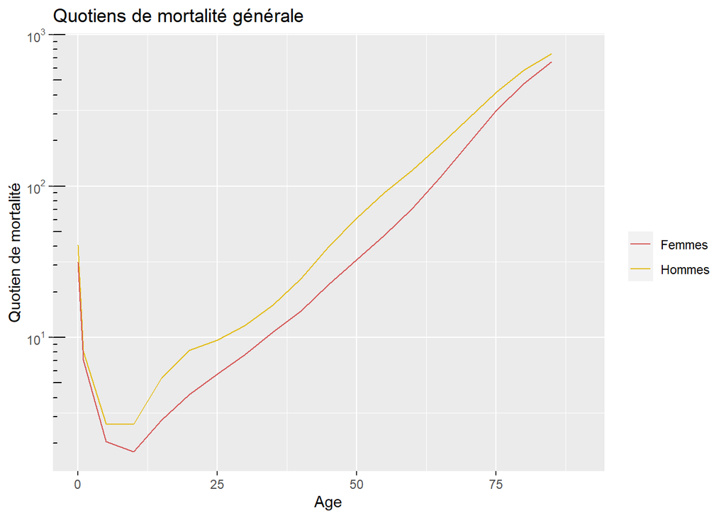

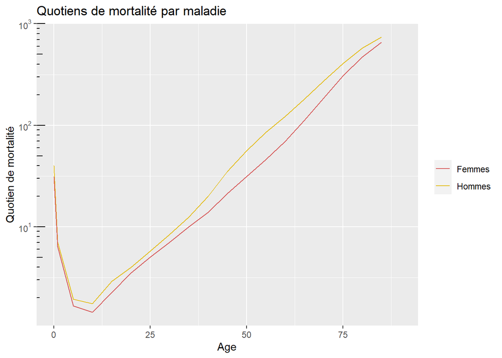

**Détailler effet d’âge, pas forcément besoir de parler des accidents, penser au noir et blanc** La mortalité générale des hommes est plus élevée que celle des femmes à tout âge. La différence s’amenuise avec le temps et un pic est constaté entre 15 et 25 ans. La mortalité due à une maladie des hommes est toujours supérieure à celle des femmes, mais la différence est beaucoup moins marquée, son pic ayant lieu autour de 55 ans.

*d- Tracer un graphique (avec une échelle semi logarithmique) avec les quotients masculins des tables I M et III M. et un autre avec les quotients féminins des tables I F et III F. Commenter.*

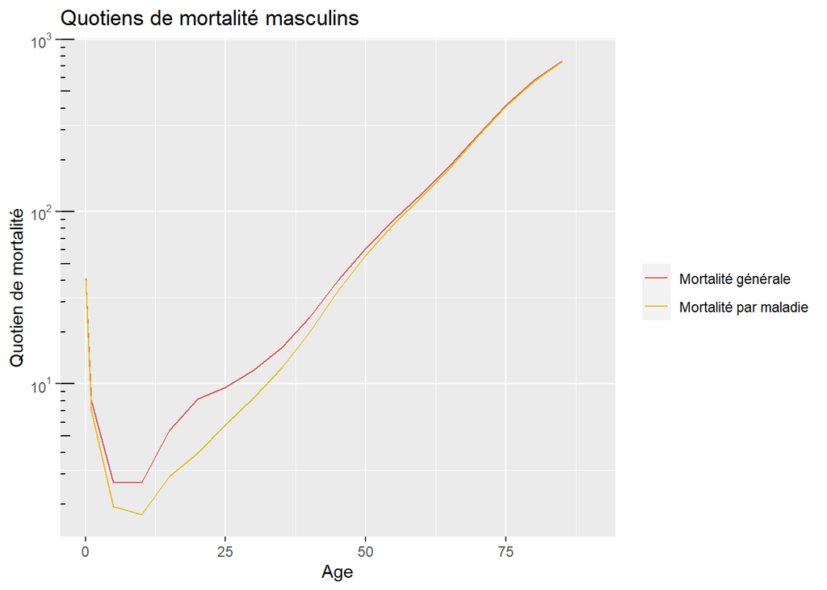

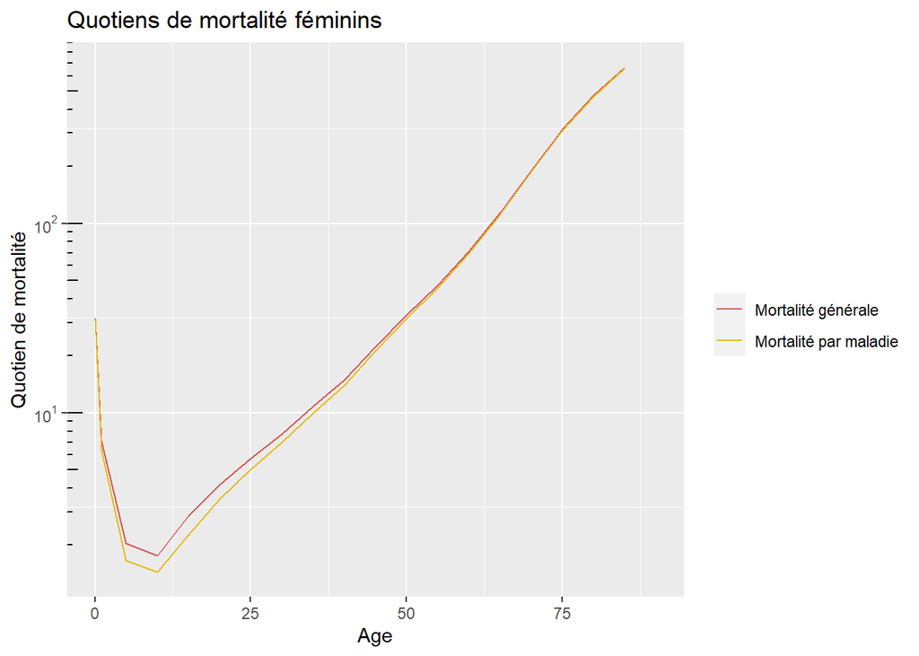

La mortalité féminine générale est quasi indistincte de la mortalité par maladie. La mortalité masculine générale est très influencée par la mortalité par maladie à partir de 40 ans. Entre la naissance et cet âge, il y a une différence constatée entre les deux valeurs, avec un pic autour de 20 ans.

*e- A partir des commentaires des questions c) et d) que conclure sur les populations d’hommes et de femmes vis-à-vis de la mortalité par accident et par maladie (en 2 ou 3 lignes maximum)*

**La mortalité par accident est negligeable à 55 ans, faibles, pire** La surmortalité des hommes autour de 20 ans, sans que le quotient de mortalité par maladie ne subisse de pic à cet âge, doit donc s’expliquer par une forte surmortalité accidentelle à ces âges. La mortalité féminine générale est quasi indistincte de la mortalité par maladie, indice que la mortalité par accident est marginale dans cette population quelque soit l’âge.

*f- Calculer les espérances de vie à la naissance dans les tables I M et I F et III M et III F et compléter le tableau ci-dessous. Commenter les valeurs obtenues et conclure.*

```r
EsperanceDeVieNaissance <- function (Age, Population) {
  Annees <- Population
  Racine <- Population[1]
  AnneesVecues <- data.frame(Population, row.names = Age)
  SommeAV <- 0
  for (i in seq_along(Age)){
    AnneesVecues$Annees[i] <- ((Population[i] + Population[i+1])/2) * (as.numeric(Age[i+1]) - as.numeric(Age[i]))
    SommeAV <- SommeAV + ifelse(!is.na(AnneesVecues$Annees[i]), AnneesVecues$Annees[i], 0)
  }
  return(round(SommeAV/Racine,2))
}
```

Espérance de vie

| Table I Sexe Masculin | Table I Sexe Feminin | Table III Sexe Masculin | Table III Sexe Feminin |
| --- | --- | --- | --- |
| 64.98 | 70.94 | 66.44 | 71.47 |

**Calculer les pourcentages est aussi une possibilité** L’espérance de vie générale des hommes est de 6 années de moins, l’impact des accidents sur l’espérance de vie des hommes est d’une année et demi alors qu’il n’est que d’une demi année pour les femmes. Sans accidents l’écart d’espérance de vie entre les sexes n’est que de 5 ans.

## Partie II : la mortalité de la population hommes et femmes réunis

*49 000 hommes et 51 000 femmes de cette génération atteignent l’âge de 55 ans. On se propose d’établir une partie de la table de mortalité par accident sexes réunis de la génération.*

*a- Combien de décès masculins par accident et par « maladie » a-t-on observé dans cette génération entre 55-60 ans, 60-65 ans, 65 et 70 ans et entre 70 et 75 ans ?*

```r
PopHomme55ans <- 49000
TableMortMasc <- TableMortMascAccident %>%
  slice(13:16) %>%
  select(`aqx p.1000`)
for (i in seq_along(TableMortMasc$`aqx p.1000`)) {
  TableMortMasc$`Px`[i] <- PopHomme55ans
  TableMortMasc$`d'(x;x+5) Accidents`[i] <- round(TableMortMasc$`Px`[i] * (TableMortMascAccident$`aqx p.1000`[i+12]/1000)*(1-(TableMortMascMaladie$`aqx p.1000`[i+12])/1000/2))
  TableMortMasc$`d'(x;x+5) Maladie`[i] <- round(TableMortMasc$`Px`[i] * (TableMortMascMaladie$`aqx p.1000`[i+12]/1000)*((1-(TableMortMascAccident$`aqx p.1000`[i+12])/1000/2)))
  PopHomme55ans <- PopHomme55ans - TableMortMasc$`d'(x;x+5) Accidents`[i] - TableMortMasc$`d'(x;x+5) Maladie`[i]
  if (i == length(TableMortMasc$`aqx p.1000`)) {
    TableMortMasc <- TableMortMasc %>% add_row(Px = PopHomme55ans)
    row.names(TableMortMasc)[i+1] <- 75
  }
}
TableMortMasc <- TableMortMasc %>% select(-`aqx p.1000`)
```

Table des mortalités masculine

|  | Px | d’(x;x+5) Accidents | d’(x;x+5) Maladie |
| --- | --- | --- | --- |
| 55 | 49000 | 272 | 4151 |
| 60 | 44577 | 254 | 5437 |
| 65 | 38886 | 241 | 6970 |
| 70 | 31675 | 219 | 8583 |
| 75 | 22873 | NA | NA |

*b- Le tableau en annexe donne le nombre de décès féminins par accident et par « maladie » observés dans la génération à ces âges. Calculer les quotients par accident (sexes réunis) 5q”a55, 5q”a60, 5q”a65 et 5q”a70 à l’aide des données d’observation et de celles obtenues à la question II-a. Que peut-on dire de ces indicateurs compte tenu des conclusions de la partie I ?*

```r
DecesFemmesObserves <- read_excel("./data/exo1/fobservee.xlsx")  %>% column_to_rownames("Age x")
Px <- DecesFemmesObserves$Px[1]
for (i in seq_along(DecesFemmesObserves$`Décés par accident observés D'a(x;x+5)`)) {
  DecesFemmesObserves$Px[i] <- Px
  Px <- Px - DecesFemmesObserves$`Décés par accident observés D'a(x;x+5)`[i] - DecesFemmesObserves$`Décés par maladie observés D'm(x;x+5)`[i]
  if (i == length(DecesFemmesObserves$`Décés par accident observés D'a(x;x+5)`)) {
    DecesFemmesObserves <- DecesFemmesObserves %>% add_row(Px = Px)
    row.names(DecesFemmesObserves)[i+1] <- 75
  }
}
DecesSexesReunis <- TableMortMasc
DecesSexesReunis$`d'(x;x+5) Accidents` <- DecesSexesReunis$`d'(x;x+5) Accidents` + DecesFemmesObserves$`Décés par accident observés D'a(x;x+5)`
DecesSexesReunis$`d'(x;x+5) Maladie` <- DecesSexesReunis$`d'(x;x+5) Maladie` + DecesFemmesObserves$`Décés par maladie observés D'm(x;x+5)`
DecesSexesReunis$Px <- DecesSexesReunis$Px + DecesFemmesObserves$Px
for (i in seq(DecesSexesReunis$Px)) {
DecesSexesReunis$`5q''ax`[i] <- round(DecesSexesReunis$`d'(x;x+5) Accidents`[i]/(DecesSexesReunis$Px[i] - (DecesSexesReunis$`d'(x;x+5) Maladie`[i]/2)) * 1000,2)
}
```

Table des décès réunis

|  | Px | d’(x;x+5) Accidents | d’(x;x+5) Maladie | 5q’’ax |
| --- | --- | --- | --- | --- |
| 55 | 100000 | 358 | 6482 | 3.70 |
| 60 | 93160 | 349 | 8796 | 3.93 |
| 65 | 84015 | 360 | 11977 | 4.61 |
| 70 | 71678 | 376 | 15992 | 5.90 |
| 75 | 55310 | NA | NA | NA |

Quand on prend les paramètres sans faire la distinction des sexes en additionnant les quotients (une sorte de moyenne), il y a une bien plus grande mortalité des femmes que constaté avec les chiffres réels. Si on reconstruit le quotient de mortalité par accident peu importe le sexe avec ces chiffres, il baisse considérablement. Avec les éléments obtenus plus haut, on en déduit que la mortalité accidentelle est bien plus présente chez les hommes que chez les femmes, même dans cette période de la vie. **C’est pas la question, ils sont biaisés**

*c-Plaçons-nous dans l’hypothèse où la mortalité par « maladie » des hommes serait égale à celle des femmes. Dans ce cas les décès masculins observés seraient les suivants. Les décès féminins restent inchangés. Calculer, dans cette hypothèse, les quotients par accident (sexes réunis) aux mêmes âges que précédemment. Les comparer aux quotients calculés à la question IIb. Commenter.*

```r
DecesHommesObserves <- read_excel("./data/exo1/mobservee.xlsx") %>% column_to_rownames("Age x")
DecesSexesReunisObs <- TableMortMasc
DecesSexesReunisObs$`d'(x;x+5) Accidents` <- DecesSexesReunisObs$`d'(x;x+5) Accidents` + DecesFemmesObserves$`Décés par accident observés D'a(x;x+5)`
DecesSexesReunis$`d'(x;x+5) Maladie` <- DecesSexesReunis$`d'(x;x+5) Maladie` + DecesFemmesObserves$`Décés par maladie observés D'm(x;x+5)`
DecesSexesReunisObs$Px <- DecesSexesReunisObs$Px + DecesSexesReunisObs$Px
for (i in seq(DecesSexesReunisObs$Px)) {
  DecesSexesReunisObs$`5qax`[i] <- round(DecesSexesReunisObs$`d'(x;x+5) Accidents`[i]/(DecesSexesReunisObs$Px[i] - (DecesSexesReunisObs$`d'(x;x+5) Maladie`[i]/2)) * 1000,2)
}
```

Table des morts par accidents

|  | Px | d’(x;x+5) Accidents | d’(x;x+5) Maladie | 5qax |
| --- | --- | --- | --- | --- |
| 55 | 98000 | 358 | 4151 | 3.73 |
| 60 | 89154 | 349 | 5437 | 4.04 |
| 65 | 77772 | 360 | 6970 | 4.85 |
| 70 | 63350 | 376 | 8583 | 6.37 |
| 75 | 45746 | NA | NA | NA |

On retrouve des quotients du même ordre qu’à la question IIa, quotients plus élevés que les quotients de la question IIb. Cela confirme que le quotient de mortalité par accident si on prend en compte la population théorique masculine et la population réelle féminine biaise les résultats, preuve que la mortalité féminine par accident est plus faible.

*d- Construire les deux tables partielles de mortalité par accident (sexes réunis), de 55 à 75 ans, correspondant aux deux séries de quotients. Calculer 20q”a55 dans les deux cas.*

```r
PopulationHommeFemme <- 100000
TableMortFunc <- function (Age, Racine, Quotients) {
  Res <- data.frame(Quotients, row.names = Age)
  for (i in seq_along(Age)){
    Res$`Sx`[i] <- Racine
    Res$`d(x;x+a)`[i] <- round(Res$`Quotients`[i] * Res$`Sx`[i] / 1000)
    Racine <- Racine - Res$`d(x;x+a)`[i]
  }
  Res <- relocate(Res, `Sx`, `d(x;x+a)`, `aqx P.1000` = `Quotients`)
  return(Res)
}
TableMortAccidentSecond <- TableMortFunc(row.names(DecesSexesReunisObs),PopulationHommeFemme,DecesSexesReunisObs$`5qax`) %>% rename(`5q''ax P.1000` = `aqx P.1000`)
TableMortAccidentObs <- TableMortFunc(row.names(DecesSexesReunis),PopulationHommeFemme,DecesSexesReunis$`5q''ax`) %>% rename(`5qax P.1000` = `aqx P.1000`)
SommeDecesSexeReunis <- sum(TableMortAccidentSecond$`d(x;x+a)`,  na.rm=TRUE)
SommeDecesSexeReunisObs <- sum(TableMortAccidentObs$`d(x;x+a)`,  na.rm=TRUE)
Quotient20qSeconda55 <- SommeDecesSexeReunis/PopulationHommeFemme * 1000
Quotient20qa55 <- SommeDecesSexeReunisObs/PopulationHommeFemme * 1000
```

|  | Sx | d(x;x+a) | 5q’’ax P.1000 |
| --- | --- | --- | --- |
| 55 | 100000 | 373 | 3.73 |
| 60 | 99627 | 402 | 4.04 |
| 65 | 99225 | 481 | 4.85 |
| 70 | 98744 | 629 | 6.37 |
| 75 | 98115 | NA | NA |

|  | Sx | d(x;x+a) | 5qax P.1000 |
| --- | --- | --- | --- |
| 55 | 100000 | 370 | 3.70 |
| 60 | 99630 | 392 | 3.93 |
| 65 | 99238 | 457 | 4.61 |
| 70 | 98781 | 583 | 5.90 |
| 75 | 98198 | NA | NA |

*e- La probabilité de décéder par accident des deux sexes réunis entre 55 ans et 75 ans (20q’’a55) est en fait une moyenne pondérée des probabilités de décéder par accident de chaque sexe aux mêmes âges, les coefficients de pondération étant les taux de masculinité et de féminité à 55 ans. Calculer cette probabilité (20q’’a55) à l’aide de cette relation.*

**Tout recalculer avec l’addition des quotients donnés 1-produit des 1-M, pour les hommes puis pour les femmes (calculer les accidents des femmes)**

```r
ProbabiliteDecesSecond <- ((SommeDecesSexeReunis/PopulationHommeFemme * 0.51) + (SommeDecesSexeReunis/PopulationHommeFemme * 0.49)) * 1000
ProbabiliteDecesObs <- ((SommeDecesSexeReunisObs/PopulationHommeFemme * 0.51) + (SommeDecesSexeReunisObs/PopulationHommeFemme * 0.49)) * 1000
```

Probabilités de mourir entre 55 et 75 ans

| Probabilité de la table de mortalité calculée | Probabilité de la table de mortalité “Observée” |
| --- | --- |
| 18.85 | 18.02 |

**Comparer les valeurs obtenues à la question IId et dire dans quel cas la relation définie ci-dessus est vérifiée. Commenter.**

## Exercice 2

Porter ces données du tableau 1 sur deux graphiques et les données du tableau 2 sur deux graphiques et commenter en portant en abscisse les générations des personnes. Commenter en étant le plus synthétique possible en montrant les effets d’âge, de génération et de sexe. **Centrer les valeurs et faire des courbes, selon l’année de naissance, date, age : nuage de points**

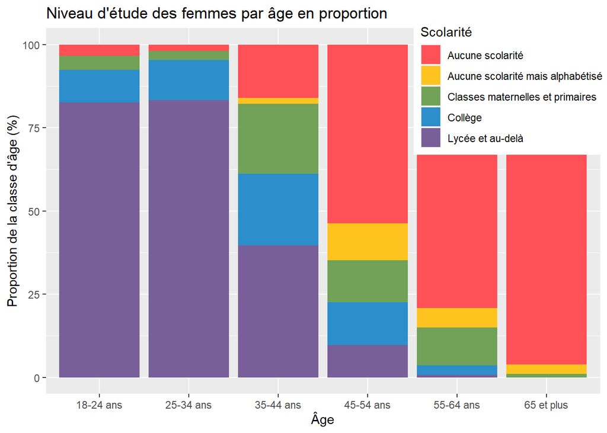

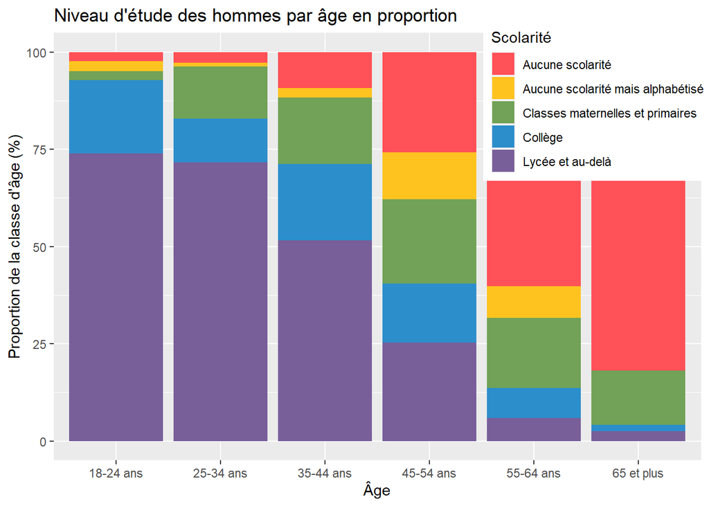

[output not shown]

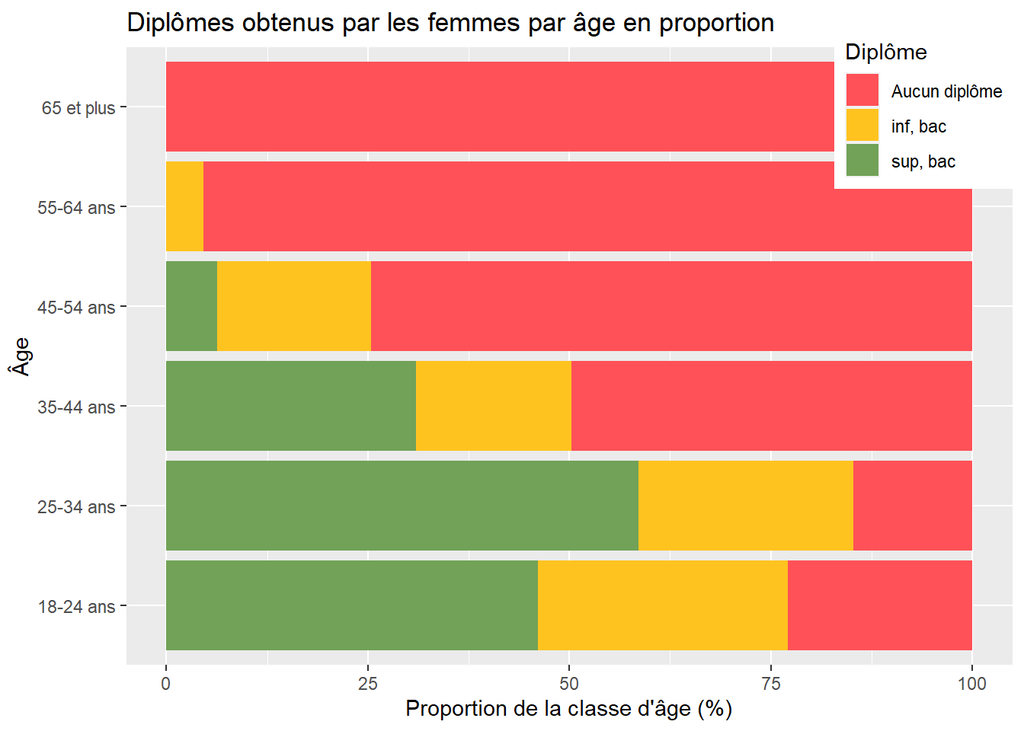

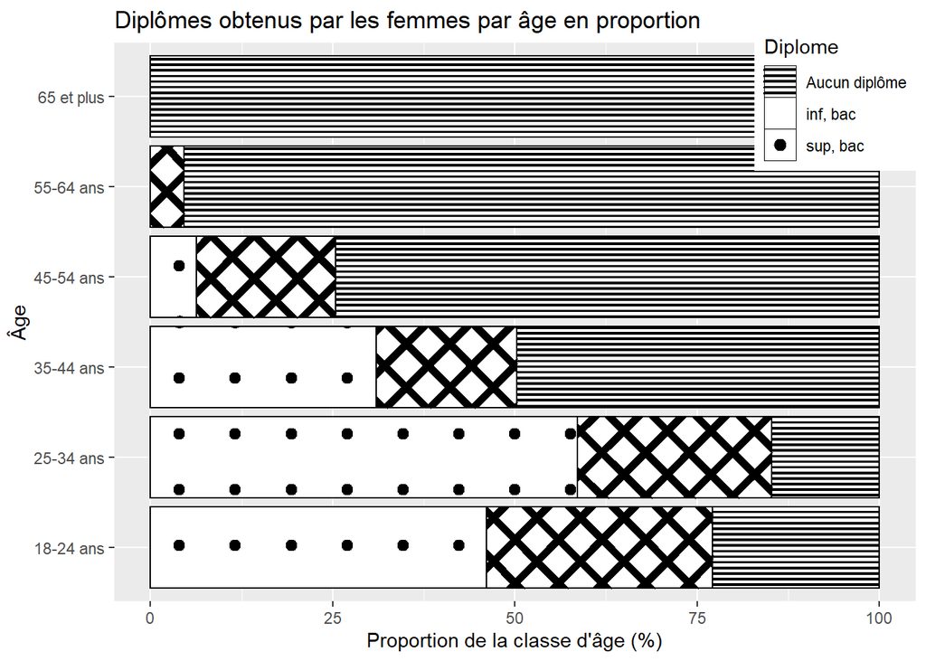

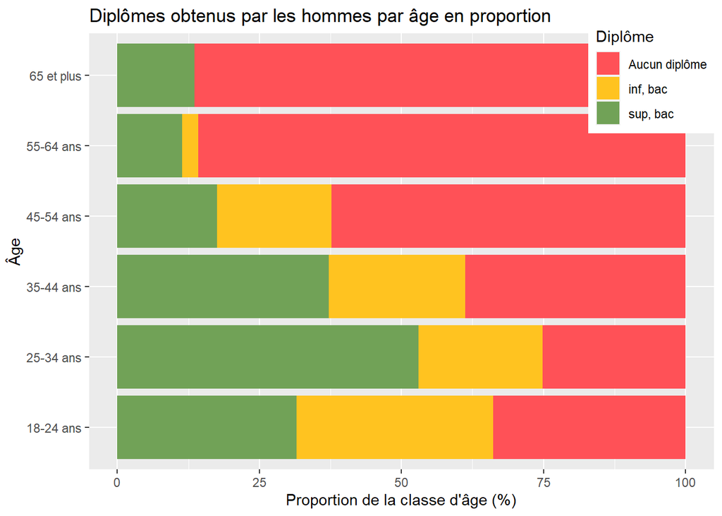

*Une enquête rétrospective réalisée en 2005 auprès d’un échantillon représentatif d’hommes et de femmes âgés de 18-79 ans, donne les renseignements suivants :*

*Un certain nombre des unions sont rompues au fil des années qui suivent la naissance. Elles sont rompues soit du fait d’une séparation, soit à cause du décès du conjoint. Les personnes déclarent les causes de la rupture de chacune de leurs unions.*

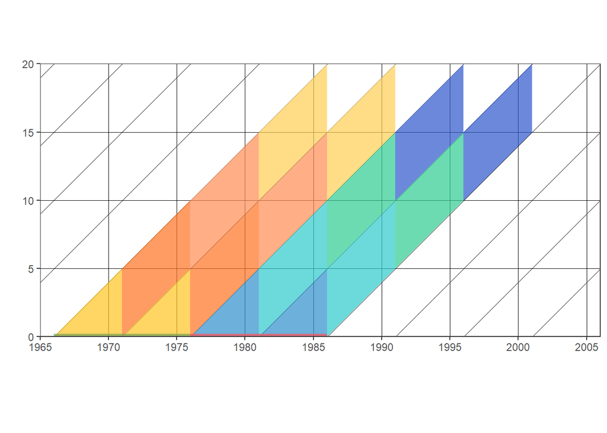

- 1362 femmes et 1041 hommes ont un enfant

- 1486 femmes et 1114 hommes ont un enfant

// 68 séparations, 13 décès de conjoint chez les femmes, 71 séparations chez les hommes

// 95 séparations, 15 décès de conjoint chez les femmes, 59 séparations, 2 décès de conjoint chez les hommes

// 107 séparations, 17 décès de conjoint chez les femmes, 59 séparations, 6 décès de conjoint chez les hommes

// 81 séparations, 21 décès de conjoint chez les femmes, 50 séparations, 7 décès de conjoint chez les hommes

// 135 séparations, 12 décès de conjoint chez les femmes, 128 séparations, 14 décès de conjoint chez les hommes

// 128 séparations, 14 décès de conjoint chez les femmes, 104 séparations, 3 décès de conjoint chez les hommes

// 110 séparations, 11 décès de conjoint chez les femmes, 58 séparations, 4 décès de conjoint chez les hommes

// 23 séparations, 5 décès de conjoint chez les femmes, 16 séparations, 2 décès de conjoint chez les hommes

*2- Comparer, pour les enfants les proportions d’enfants vivant encore avec ses deux parents à 19 ans révolus (vivant et encore en couple) dans chacun des 4 cas. Commenter. Ces mesures sont-elles des mesures brutes ou nettes ? Expliciter.*

```r
EnfantsDeuxParentsF66.75 <- round((PopFEnfants66.75 - sum(FinUnionFEnfants66.75$`Décès du conjoint`) - sum(FinUnionFEnfants66.75$`Séparation`))/PopFEnfants66.75 * 100,2)
EnfantsDeuxParentsH66.75 <- round((PopHEnfants66.75 - sum(FinUnionHEnfants66.75$`Décès du conjoint`, na.rm =TRUE ) - sum(FinUnionHEnfants66.75$`Séparation`))/PopHEnfants66.75 * 100,2)
EnfantsDeuxParentsF76.85 <- round((PopFEnfants76.85 - sum(FinUnionFEnfants76.85$`Décès du conjoint`) - sum(FinUnionFEnfants76.85$`Séparation`))/PopFEnfants76.85 * 100, 2)
EnfantsDeuxParentsH76.85 <- round((PopHEnfants76.85 - sum(FinUnionHEnfants76.85$`Décès du conjoint`) - sum(FinUnionHEnfants76.85$`Séparation`))/PopHEnfants76.85 * 100,2)
```

| Nés entre 1966 et 1975 Selon les mères | Nés entre 1966 et 1975 Selon les pères | Nés entre 1976 et 1985 Selon les mères | Nés entre 1976 et 1985 Selon les pères |
| --- | --- | --- | --- |
| 69.38 | 75.6 | 70.52 | 73.43 |

*Proportions d’enfants vivant encore avec ses deux parents à 19 ans révolus (en %)*

Les pères ont tendance à moins déclarer leurs enfants comme vivant sans leurs deux parents que les mères. Ces mesures sont nettes, elles décrivent une proportion finale sans isolations d’évènements spécifiques.

*3- Utiliser les méthodes d’analyse démographique pour comparer l’évolution des probabilités de connaître la séparation par rupture de ses parents dans les différentes cohortes et selon le sexe du répondant (construction de tables). Commenter.*

```r
#FinUnionFEnfants66.75 <- FinUnionFEnfants66.75 %>% mutate(`5dx` = )
```

*4- Quelles hypothèses faites-vous pour le calcul du point 3.*

*5- Calculer les indices de calendrier de séparation par rupture d’avec ses parents dans les différentes générations d’enfants selon que ce soit le père ou la mère qui réponde. Commenter.*